# Functional-programming-and-eUTXO.knit

# Smart Contracts in Cardano

## Part II: Specifications and Validators

**Claudio Hermida**  
claudio.hermida@gmail.com  
https://www.linkedin.com/in/claudiohermida/

## Abstract

> The purpose of this work is to
> > - Show how the eUTxO model of blockchain comes about from a consideration of handling state in functional programming
> > - Exhibit Cardano’s validators as verifiable specifications of a contract-method input-output behaviour
> > - Provide a putative answer to the question: what is a smart contract in Cardano?

> This is the second in a three-part series covering these topics.
- Introduction
- Specification in the small: methods, pre- and post-conditions
- Specifying a transaction: validators
- Validators and contract methods
- References

# Introduction

In the first part of this series we recalled how functional programming handles state and its relevance to understand Cardano’s eutxo model.

In this second part, we focus on the more original aspect of Cardano’s approach to smart contract, namely *transaction validation*, making emphasis on Cardano’s radical difference wrt the account-based model, namely, off-chain computation of transactions and their on-chain validation. We thus are led to write out the whole specification that a transaction must satisfy, namely the conjunction of validators for its inputs plus the *preservation of values* balancing condition.

We recall the traditional approach to specifying the extensional behaviour of programs (that is, their input-output behaviour) by means of (first-order logic) *pre* and *post*-conditions, which we treat as boolean-valued functions in our programming language, leading to their use as *validators* for the corresponding *redeemer* method. We illustrate these notions with our guiding example of a Solidity smart contract implementing a *Vesting* escrow.

The third part of this series addresses the relation of smart contract methods and their off-chain counterpart via transaction schemas, and rounds up our treatment of smart contracts, including their deployment.

# Transactions

In the account-based model, a transaction transforms the global state of the blockchain. A transaction executes a *contract call*, whereby we invoke a method of a contract with specific arguments and the current state of the blockchain (meaning all the accounts’ local states indexed by their addresses) as inputs, producing an updated global state as output. This execution is carried *on-chain* by all the nodes involved in the processing of the transaction for its eventual inclusion in a block.

The most radical difference of Cardano’s eUTXO model is its treatment of transactions: in Cardano

> **a transaction is computed off-chain and validated on-chain**

On-chain validation is the key feature of the Cardano blockchain. A **validator** is a predicate which will indicate whether an input eutxo can be consumed by the transaction; it has the following signature:

```haskell
validator :: Datum -> Redeemer -> ScriptContext -> Bool
```

Here `Datum` is the datum in the input eutxo we are attempting to consume, `Redeemer` is the action/method whose execution we are validating and `ScriptContext` indicates both the purpose of the script to be executed (spending an input, minting tokens, staking, etc.) and the transaction context (its inputs, outputs, and signatures).

Recall that we are operating under the functional-programming paradigm, so the only *actual* input that we provide to a validator is the redeemer, which is the equivalent of a *method signature* (name and arguments). Datum is a piece of *local state* encoded in the input eutxo, while the script context is the piece of *global state* the transaction has access to; both datum and script context are supplied to the validator by the Cardano node processing the transaction.

Presently, there are two major kinds of input eutxos<sup>(CIP-31)</sup>:

1. eutxos held at a PublicKeyHash (pkh) address: these are the values held at an addreess controlled by a private key, which is required in the signature to unlock/spend such eutxo.
2. eutxos held at a *script address*: a script address is uniquely associated to a validator (via hashing) and it is controlled by it. In order to unlock such eutxo, a node evaluates the validator (with a supplied redeemer); if it succeeds, the eutxo may be spent.

If all inputs of a transaction validate successfully (either by validator or signature), such inputs are consumed and its outputs are added to the ledger. Otherwise, the trasaction *fails* and no changes occur in the ledger.

Let us elaborate the process of *building* and *executing* a transaction:

- we *build* a transaction by specifying its inputs (eutxos) and its would-be outputs (eutxos). Here, eutxos are treated as mere *data*, not resources, since we are off chain. We also indicate the signer of the transaction, which pays for the *transaction fees* (supplied as one of the inputs eutxo). In order to specify outputs, some computation might take place from the given inputs (method execution); this is the off-chain (pre)computation of a transaction. We produce a so-called *transaction body*,
- we *sign and submit* the transaction body for *validation*: each input held at a script triggers the execution of the corresponding validator and each input held at a pkh is signature-verified.
- if all inputs validate and the transaction satisfies preservation-of-values (that is, inputs and outputs are balanced), the transaction submission is *successful* and the ledger gets updated: inputs are spent (eliminated) and outputs are created (added): the triples of `(address,value,datum)` of our would-be outputs get uniquely referenced by the transaction-id we have just validated, together with the respective index, becoming genuine *eutxos*.

If any of the inputs fails to validate or the transaction is not properly balanced, the transaction *fails* and has no effect on the ledger.

The eUTXO model lends itself to a very simple modelling<sup>[@brunjes2020modellingutxo]</sup> of a distributed ledger: it is the set or collection of eutxos

```
 Ledger = { eutxo }
```

The blockchain itself is nothing more than a sequence of transactions (grouped in blocks), such that the inputs of one transaction are outputs of transactions occurring earlier in the sequence.

```
Blockchain = [block]
block = {tx}
```

There is no structure associating utxos to a given address; that information has to be collected by inspecting the blockchain.

A transaction consumes its inputs and produces new outputs:

```
tx :  Ledger  ~~~~~>   ( Ledger - inputs ) + outputs
```

Let us compare the salient aspects of transactions on both models:

| **Account based** |
| --- |
| - Transaction signed and submitted to a node |
| - Changes to the ledger effected **on-chain** by means of state updates of the accounts involved in the transaction |
| - Protected execution **on-chain**: if anything fails, it *reverts* to initial state of the ledger before transaction execution started, using a snapshot of the state taken at the start of execution |
| - **Validation** mixed with **execution**, by means of **require** statements |
| - Access to accounts during execution could be unrestricted (Ethereum) or restricted to pre-specified ones at transaction-build time (Algorand) |

| **eUTXO based** |
| --- |
| - Transaction signed and submitted to a node |
| - Outputs of a transaction **precomputed off-chain;** |
| - (Inputs, Outputs) fed as transaction context to cardano-node at transaction-build time |
| - (Inputs, outputs) are subject to **validation** in the node (**on-chain**) before effecting a change on the distributed ledger |

### Reference input

Since the Vasil hardfork, CIP-31 (Peyton Jones 2021b) was implemented allowing for a new kind of input: **reference input**. It allows transactions to simply treat some inputs as *read-only data* rather than *resources*: we can read their value and datum, but not modify them. That way we avoid the waste of compute in consuming and (re)producing a given utxo just to read its content. ↩︎

# Specification in the small: methods, pre- and post-conditions

Consider a sorting function which orders a list of integers in increasing order:

`sortIncOrder: List(Int) -> List(Int)`

Beyond our intuitive understanding which we can illustrate with examples `sortIncOrder [8,2,5] == [2,5,8]`, how do we formally specify such a function? For starters, we want the output increasingly ordered

```haskell
Ordered:: List(Int) -> Bool
Ordered [] = True
Ordered [n] = True
Ordered n:(m:l) = n \leq m && Ordered(m:l)

forall l:List(Int). Ordered(sortIncOrder(l))
```

That is not enough, otherwise simply returning the empty list would do. We also expect the output list to a be a rearrengement or *permutation* of the input list

```haskell
isPermutation:: List(Int) -> List(Int) -> Bool

isPermutation []    []  = True

isPermutation (h:t) l = (h `elem` l) && isPermutation t (l \ h)

forall l: List(Int). isPermutation(l,sortIncOrder(l))
```

Now we have a sound *specification* of what a sorting function should do, regardless of its implementation (quick sort, bubble sort, etc.)

Consider a functional program (or a procedural program modelled as a function)

`f:I -> O`

Given an input `i: I` it produces (if it terminates) an output `fi: O`. In order to *specify* its expected (extensional) behaviour, we must indicate a couple of predicates, called *precondition* and *postcondition*. The *precondition* constraints what kind of inputs should the function expect, while the postcondition indicates how inputs and outputs should relate. The specification states > *for every input that satisfies the precondition, it and the result satisfy the postcondition*

which is expressed in first-order logic as

> $$\forall
> i\,\colon\,I\,.\,\,\mathsf{Pre}(i) \Longrightarrow \mathsf{Post}(i,
> fi)$$

### Examples

- For `sortIncOrder` we have no precondition as it should work for all lists, so we get

```haskell
    Spec(sortIncOrder) = forall l:List(Int). isSorted(sortIncOrder(l)) && isPermutation(l,sortIncOrder(l))
```

- As another example consider the following piece from the *Aiken stdlib* https://aiken-lang.github.io/stdlib/aiken/transaction/value.html (we elaborate on Values later on<sup>Values</sup>):

  `from_asset_list(xs: List<(PolicyId, List<(AssetName, Int)>)>) -> Value`

  Promote an arbitrary list of assets into a Value. This function fails if (*Precondition*):
  - there’s any duplicate amongst PolicyId; `nodup $ map fst xs`
  - there’s any duplicate amongst AssetName; `all $ map (nodup $ map fst) xs`
  - the AssetName aren’t sorted in ascending lexicographic order; `all (Ordered map fst)`
  - or any asset quantity is null. `none $ concat (map (map (\(assetName,qty) -> qty == 0)))`

  This function is meant to turn arbitrary user-defined Data into safe Value, while checking for internal invariants. The result should be the addition of the values represented by each individual entry `(PolicyId,AssetName,Int)`, which we write as `SingletonValue`. So, the *Postcondition* is:

  `from_asset_list (xs) == foldr <> mempty $ concat (map (\pid -> map (\(an,qty) -> SingletonValue(pid,an,qty))) xs`

The specification above is a *partial specification*, as it does not constrain the program behaviour when the precondition does not hold. However, in blockchains, we do know that when the precondition of a method call does not hold, the execution should revert; in other words, if the precondition does not hold, the specification is falsified. In summary, we want

```haskell
Spec(f) =
    forall i:I. Pre(i) ==> Post(i,fi) &&  !Pre(i) ==> false
```

This is equivalent to the more concise

```haskell
Spec(f) = forall i:I. Pre(i) && Post(i,fi)
```

## Specifying a transaction: validators

A transaction in Cardano is a function on **resource types**, which consumes inputs and produces outputs. Just like data types specifiy collections of elements on which one can perform certain operations (like arithmetic operations on intergers or floats), resource types (or *linear types*) specify collections of elements which, in addition to the operations we can perform on them, are **produced** and **consumed**. Once produced, they can be used *only once* (consumed).

Remember that in Cardano, `LEDGER = {eutxo}` and a transaction in Cardano is a function `tx: LEDGER → LEDGER` whose effect is

```haskell
tx(L) = (L - {inputs tx}) + {outputs tx}
```

with `inputs tx` being a set of utxos and `outputs tx` a list of utxos, regarded as a set with their unique identifiers via their position in the output list of the transaction.

A transaction tx

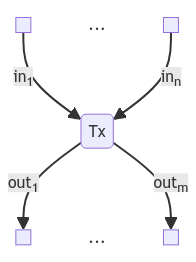

must satfisfy its *specification*:

> *SPEC(tx) = validator*<sub>1</sub> (datum(in<sub>1</sub>), redeemer<sub>1</sub>, sc<sub>1</sub>) ∧ … ∧ validator<sub>n</sub>(datum(in<sub>n</sub>),redeemer<sub>n</sub>, sc<sub>n</sub>) ∧ Preservation-of-Value(sc)

where **sc**<sub>i</sub> is the script context associated to **in**<sub>i</sub> to unlock it, and

> *Preservation-of-Value(scriptContext)* = “sum of values of inputs plus value minted = sum of values of outpus plus tx fee”:

> *Value(in*<sub>1</sub>) + … + Value(in<sub>n</sub>) + Value(forge(tx)) = Value(out<sub>1</sub>) + … + Value(out<sub>m</sub>) + Fee(tx)

or, in Plutus notation:

value (in<sub>1</sub>) <> … <> value(in<sub>n</sub>) <> txInfoMint == value’(out<sub>1</sub>) <> … <> value’(out<sub>m</sub>) <> txInfoFee

where  
value :: TxInInfo -> Value  
value in = txOutValue $ txInInfoResolved in

value’:: TxOut -> Value  
value’ = txOutValue

### Value

In Cardano, the type **Value** amounts to a bag of assets

```
Value = Bag(AssetClass)

AssetClass = {unAssetClass :: (CurrencySymbol, TokenName)}
```

This is **not** the definition of Value in the Plutus repository, but merely its abstract algebraic characterisation. The Value type is implemented via nested maps (as outlined in our second example , which shows additional constraints imposed on such maps to be considered values).

A bag (also called a *multiset*) is a list where ‘order does not matter’; all that matters is the number of occurrences or repetitions of an element in the bag. Just like, for a given set A, List(A) is the *free monoid* on A, Bag(A) is the *free commutative monoid* on A; it is crucial for the above formula of preservation of value that the operation <> be commutative as well as associative.↩︎

### Validators and contract methods

How are we to use validators in the context of implementing smart contracts? The answer is:

> *A validator specifies the pre- and post-condition of a contract method*

Let us illustrate this with our running example of a vesting contract. Consider the method `claim()`: we deduce from it a `Validator (dat,Claim,ctx)` and a *transaction schema* which gets instantiated into a concrete transaction to submit to the blockchain once we fill in its required inputs and compute its outputs:

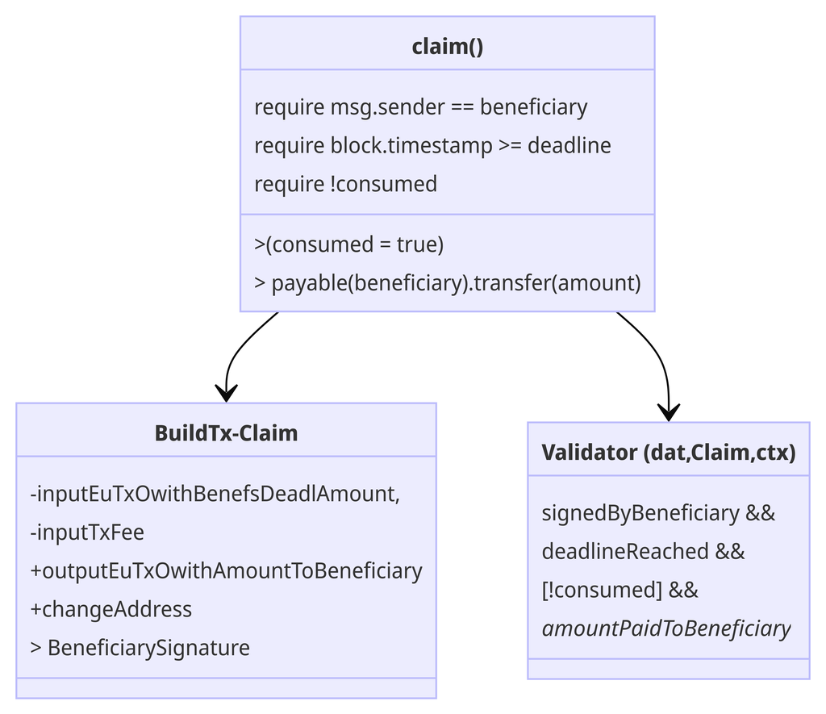

Here is the full Haskell code for the validators of our smart contract:

```haskell
data VestingDatum = VestingDatum
    { beneficiary :: PubKeyHash
    , benefactor: PubKeyHash
    , deadline    :: POSIXTime
    , amount: Integer
    }

unstableMakeIsData ''VestingDatum

data VestingRedeemer = Claim | Cancel

unstableMakeIsData "VestingRedeemer

{-# INLINABLE mkVestingValidator #-}

mkVestingValidator :: VestingDatum -> VestingRedeemer -> ScriptContext -> Bool
mkVestingValidator dat Claim ctx =
    let
    -- PRECONDITIONS
        signedByBeneficiary = txSignedBy info $ beneficiary dat
        deadlineReached = contains (from $ deadline dat) $ txInfoValidRange info
    -- POSTCONDITION
        amountPaidToBeneficiary = ( (getSignerAdaAmount info beneficiary) == amount dat)

    in
        traceIfFalse "beneficiary's signature missing" signedByBeneficiary &&
        traceIfFalse "deadline not reached" deadlineReached &&
        traceIfFalse "wrong amount paid" amountPaidToBeneficiary
  where
    info :: TxInfo
    info = scriptContextTxInfo ctx

  -- extract the integer denominator (lovelace) of the Ada value of the outputs sent to a given address:
    getSignerAdaAmount :: TxInfo -> PubKeyHash ->Integer
    getSignerAdaAmount info addr = valueOf (valuePaidTo info addr) adaSymbol adaToken



mkVestingValidator dat Cancel ctx =
    let
    -- PRECONDITIONS
        signedByCreator = txSignedBy info $ from $ scriptContextTxInfo ctx
         deadlineNotReached = contains (to $ deadline dat) $ txInfoValidRange info
    -- POSTCONDITION
        amountPaidToBenefactor = ( (getSignerAdaAmount info benefactor) == amt)
    in
        traceIfFalse "creator's signature missing" signedByCreator &&
        traceIfFalse "deadline reached" deadlineNotReached &&
 traceIfFalse "wrong amount paid" amountPaidToBenefactor
  where
    info :: TxInfo
    info = scriptContextTxInfo ctx
```

A few differences are worthy of notice between the formulation of requirements/preconditions in both models:

- In the account-based model, since the contract methods operate on the whole state of the contract, we must use a boolean flag `consumed` to indicate whether the portion of the contract balance which is vested has already been consumed or not. This effectively turns that portion of the balance (state) into a *resource managed by the flag*: it is turned off when created and turned on when consumed or spent. In the validators, the resource-nature of eutxos makes this flag unnecessary: an input eutxo is either available or not, the node validating a transaction checks that for us.
- Conversely, we might notice that in the account-based model, the transfer of `amount` to `beneficiary/benefactor` is achieved by invoking a system-defined method `payable(beneficiary).transfer(amount)` which has its own (prespecified) pre and postconditions: *pre* is simply that `this.balance() >= amount` (sufficient funds available) and *post* is

```javascript
 address(this).balance()_after == address(this).balance()_before - amount &&
 beneficiary.balance()_after == beneficiary.balance()_before + amount
```

Notice that this postcondition refers to the implicit *state* and we actually have to reference the state `_before` and `_after` the execution of `transfer`.

The validator, on the other hand, cannot know whether the funds unlocked will satisfy the transfer postcondition; we only know that the value in the input will be consumed, but we must ensure that it reaches the beneficiary/benefactor, hence the additional check `amountPaidToBeneficiary` or `amountPaidToBenefactor` respectively.